# Adopción de IPv6 en Países de la Región

## Resumen ejecutivo: Adopción de IPv6 en Brasil

El presente documento muestra el nivel de adopción de IPv6 por parte de proveedores de Internet de Brasil estimado a través de comportamientos observables externamente.

Los datos presentados corresponden al **20170814**.

## Breve descripción de la metodología de medición

Los operadores de red o prestadores de servicios se identifican mediante sus números de sistema autónomo (ASN). Los números de ASN constituyen un identificador único de un operador en Internet.

Los datos presentados aquí son relevados por un sistema de mediciones elaborado por investigadores de APNIC (El RIR de la región de Asia-Pacífico). El mecanismo de la medición consiste en presentar a los usuarios contenido web con algunos elementos alcanzables únicamente por IPv6, otros alcanzables por ambos protocolos y otros solo por IPv4. De esta manera es posible clasificar la capacidad de utilizar IPv6 por parte de un usuario en dos grandes conjuntos:

- “IPv6 Capable”: el usuario tiene la posibilidad de utilizar IPv6 para alcanzar ciertos contenidos
- “IPv6 Preferred”: el usuario no solo tiene la posibilidad de utilizar IPv6 sino que en caso de poder usar tanto IPv4 como IPv6, **prefiere IPv6**

Idealmente todos los usuarios deberían caer en este último conjunto. Sin embargo, por diferentes motivos existen casos donde los usuarios pueden utilizar IPv6 pero no lo prefieren.

Conviene destacar que esta preferencia no es controlada por el usuario sino que es el resultado de las características de la red y del software de cada usuario.

APNIC utiliza Google AdWords como el vehículo por el cual se logra la presentación de estos contenidos web a los usuarios en grandes cantidades y distribuidos geográficamente de una manera relativamente uniforme.

Esta metodología de medición si bien resulta extremadamente útil también tiene ciertas limitaciones, entre ellas, a saber:

- Tiende a sub-estimar la penetración de IPv6 a nivel de operadores móviles, debido a la forma que los navegadores de smartphones presentan los AdWords al usuario
- Puede sub-estimar la penetración IPv6 en redes donde por alguna razón los AdWords son filtrados o alterados de alguna forma por el operador mismo
- Hay un cierto sesgo que se introduce debido a la forma en la que se distribuyen a lo largo del día las impresiones de los AdWords

## Mediciones en Brasil: Adopción de IPv6

**Observación**: La cantidad de muestras es proporcional al tamaño y cantidad de usuarios de cada operador. Cuantas más muestras se observan, mayor es la cantidad de usuarios que tiene el operador.

```
##      ASN                            ORG_NAME IPv6Cap IPv6Pref SAMPLES
## 1  28573                          CLARO S.A.  32.318   31.175  380684
## 2  18881                Telefonica Data S.A.  32.971   31.867  243474
## 3   7738                             Oi S.A.  17.619   17.016  199005
## 4   8167 Brasil Telecom S/A - Filial Distrit  12.312   12.038  117939
## 5  27699                TELEFONICA DO BRASIL  30.415   29.176  160996
## 6  26615                    Tim Celular S.A.  30.456   28.885   56550
## 7  26599                Telefonica Data S.A.  40.510   39.705   48318
## 8  28158      Ampernet Telecomunicações Ltda   0.000    0.000   35295
## 9  53006        CTBC MULTIMIDIA DATA NET S/A   0.146    0.105   30744
## 10 28126 BRISANET SERVICOS DE TELECOMUNICACO   0.025    0.016   18714
```

La columna de cantidad de muestras de alguna manera indica el tamaño del operador en cantidad de usuarios. Cuanto mayor es este valor quiere decir que mayor es la base de usuarios a la que Google le presenta sus AdWords.

## Actividad IPv6 en los Top10

A continuación se muestra la actividad IPv6 para los operadores Top 10 de Brasil. En cada caso se grafican los datos del último año y se muestran los promedios para el último año y los últimos 30 días.

## Actividad para el ASN 28573

- Nombre organización: **CLARO S.A.**
- Promedio de actividad IPv6 ultimos 30 dias: 36.372 %
- Máximo de actividad IPv6 ultimos 30 dias: 36.82 %
- Promedio de actividad IPv6 ultimos 360 dias: 20.4981592039801 %
- Máximo de actividad IPv6 ultimos 360 dias: 36.82 %

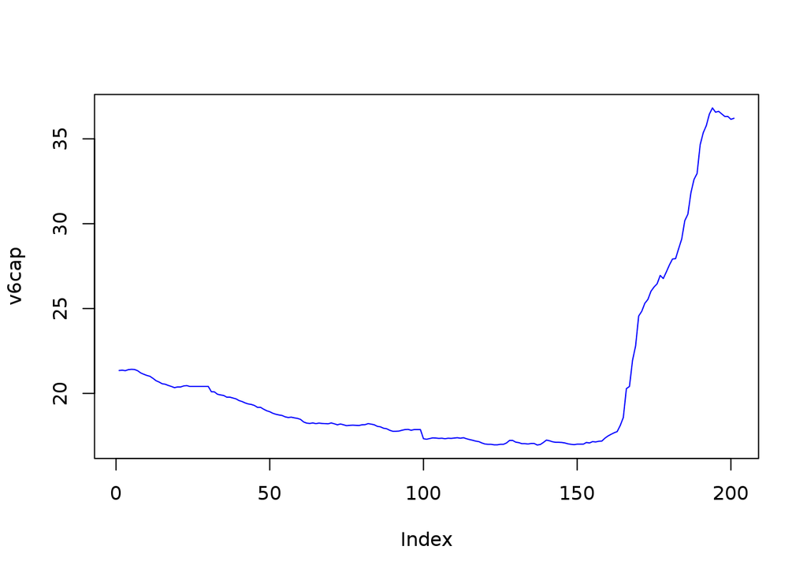

## Actividad para el ASN 18881

- Nombre organización: **Telefonica Data S.A.**
- Promedio de actividad IPv6 ultimos 30 dias: 33.485 %
- Máximo de actividad IPv6 ultimos 30 dias: 35.04 %
- Promedio de actividad IPv6 ultimos 360 dias: 23.7600995024875 %
- Máximo de actividad IPv6 ultimos 360 dias: 36.55 %

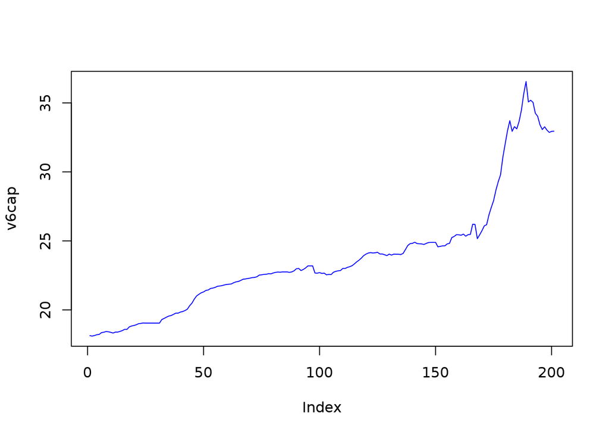

## Actividad para el ASN 7738

- Nombre organización: **Oi S.A.**
- Promedio de actividad IPv6 ultimos 30 dias: 22.37125 %
- Máximo de actividad IPv6 ultimos 30 dias: 23.21 %
- Promedio de actividad IPv6 ultimos 360 dias: 8.26894179894179 %
- Máximo de actividad IPv6 ultimos 360 dias: 23.21 %

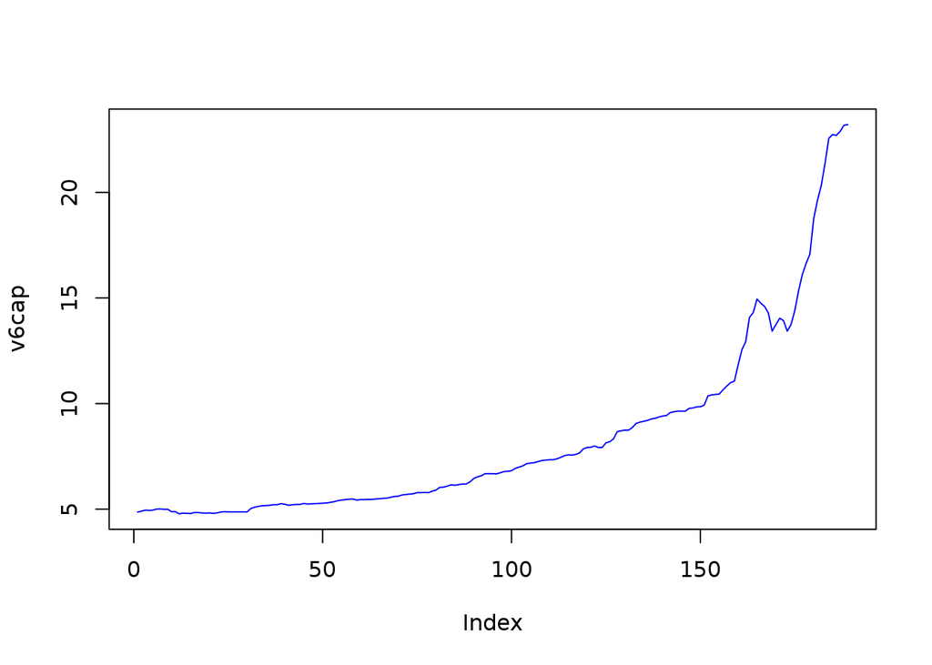

## Actividad para el ASN 8167

- Nombre organización: **Brasil Telecom S/A - Filial Distrit**
- Promedio de actividad IPv6 ultimos 30 dias: 16.082 %
- Máximo de actividad IPv6 ultimos 30 dias: 16.69 %
- Promedio de actividad IPv6 ultimos 360 dias: 6.12566137566138 %
- Máximo de actividad IPv6 ultimos 360 dias: 16.69 %

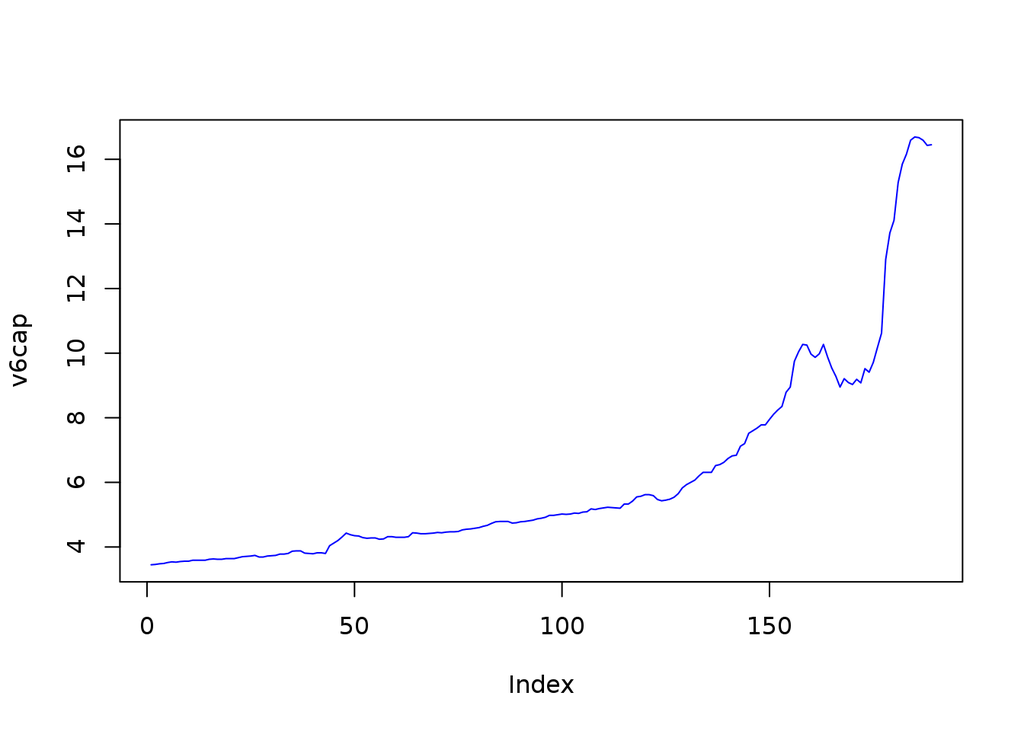

## Actividad para el ASN 27699

- Nombre organización: **TELEFONICA DO BRASIL**
- Promedio de actividad IPv6 ultimos 30 dias: 37.05125 %
- Máximo de actividad IPv6 ultimos 30 dias: 37.69 %
- Promedio de actividad IPv6 ultimos 360 dias: 15.4243410852713 %
- Máximo de actividad IPv6 ultimos 360 dias: 37.69 %

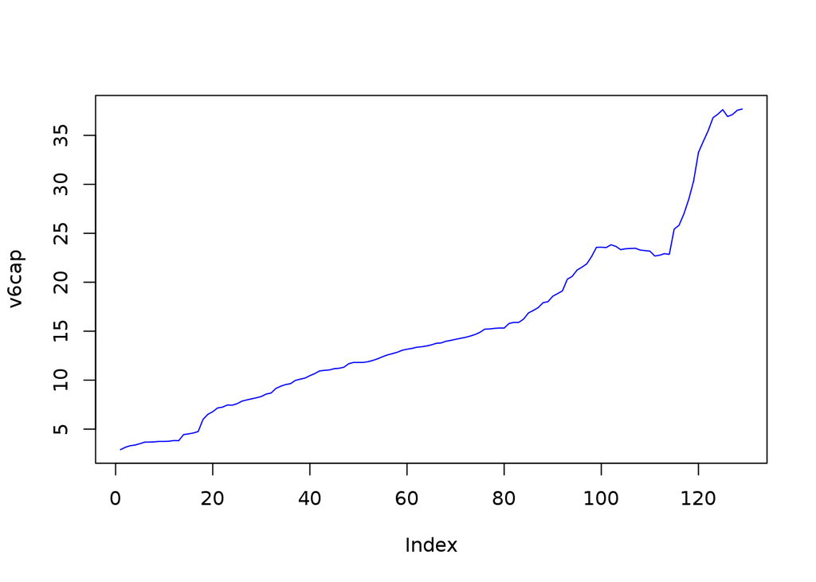

## Actividad para el ASN 26615

- Nombre organización: **Tim Celular S.A.**
- Promedio de actividad IPv6 ultimos 30 dias: 37.1744444444444 %
- Máximo de actividad IPv6 ultimos 30 dias: 37.74 %
- Promedio de actividad IPv6 ultimos 360 dias: 11.9659217877095 %
- Máximo de actividad IPv6 ultimos 360 dias: 37.74 %

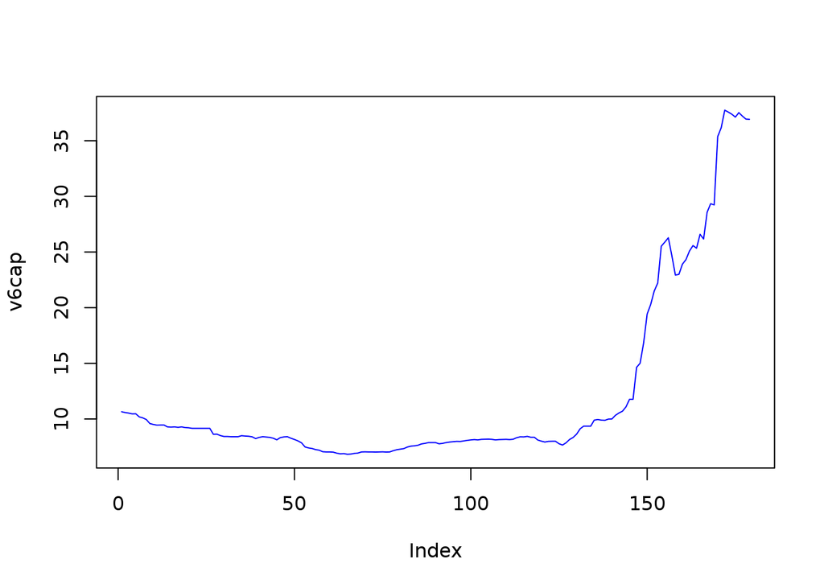

## Actividad para el ASN 26599

- Nombre organización: **Telefonica Data S.A.**
- Promedio de actividad IPv6 ultimos 30 dias: 45.09125 %
- Máximo de actividad IPv6 ultimos 30 dias: 45.56 %
- Promedio de actividad IPv6 ultimos 360 dias: 25.1302898550725 %
- Máximo de actividad IPv6 ultimos 360 dias: 45.56 %

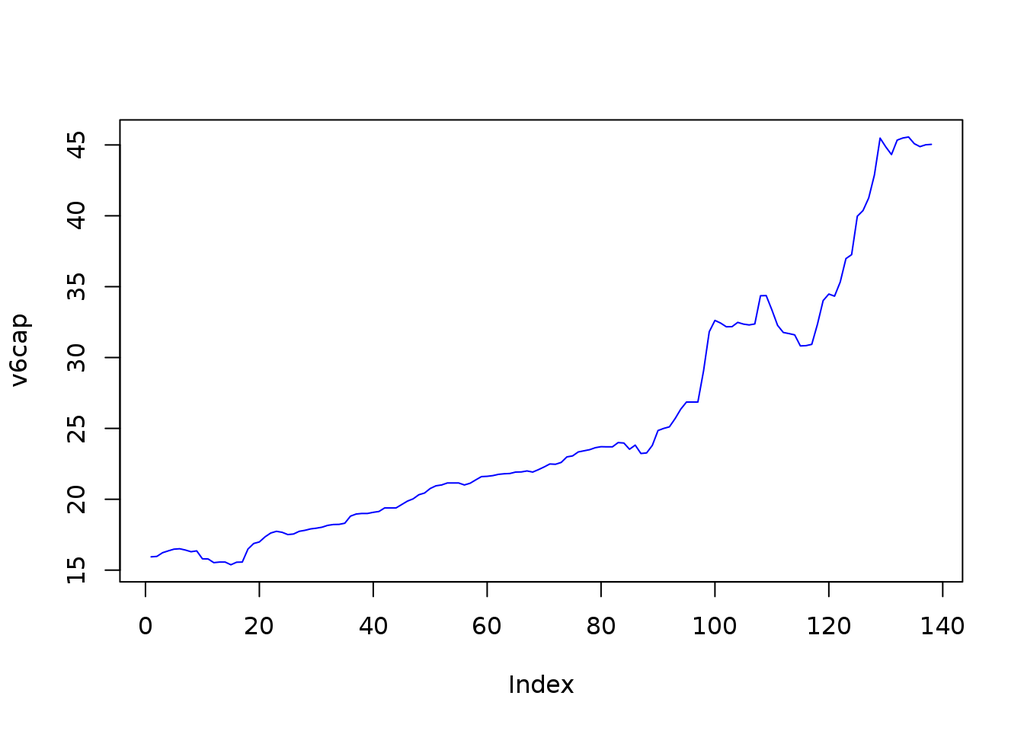

## Actividad para el ASN 28158

- Nombre organización: **Ampernet Telecomunicações Ltda**
- Promedio de actividad IPv6 ultimos 30 dias: 0 %
- Máximo de actividad IPv6 ultimos 30 dias: 0 %
- Promedio de actividad IPv6 ultimos 360 dias: 0.0385321100917431 %
- Máximo de actividad IPv6 ultimos 360 dias: 0.1 %

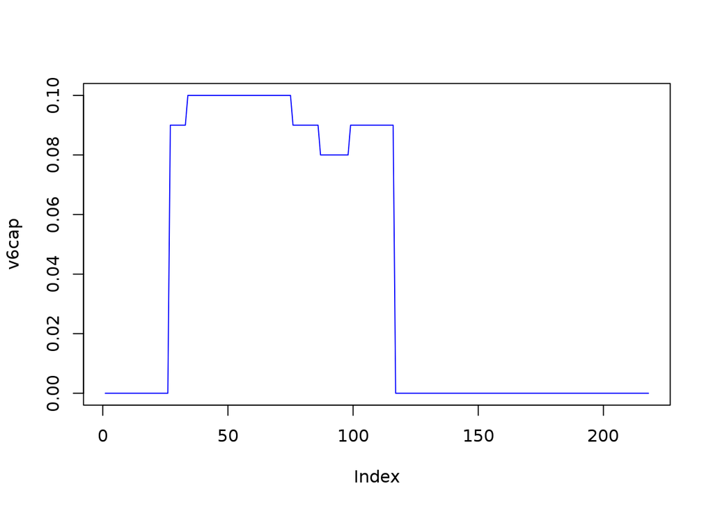

## Actividad para el ASN 53006

- Nombre organización: **CTBC MULTIMIDIA DATA NET S/A**
- Promedio de actividad IPv6 ultimos 30 dias: 0.144444444444444 %
- Máximo de actividad IPv6 ultimos 30 dias: 0.2 %
- Promedio de actividad IPv6 ultimos 360 dias: 0.0838423645320197 %
- Máximo de actividad IPv6 ultimos 360 dias: 0.26 %

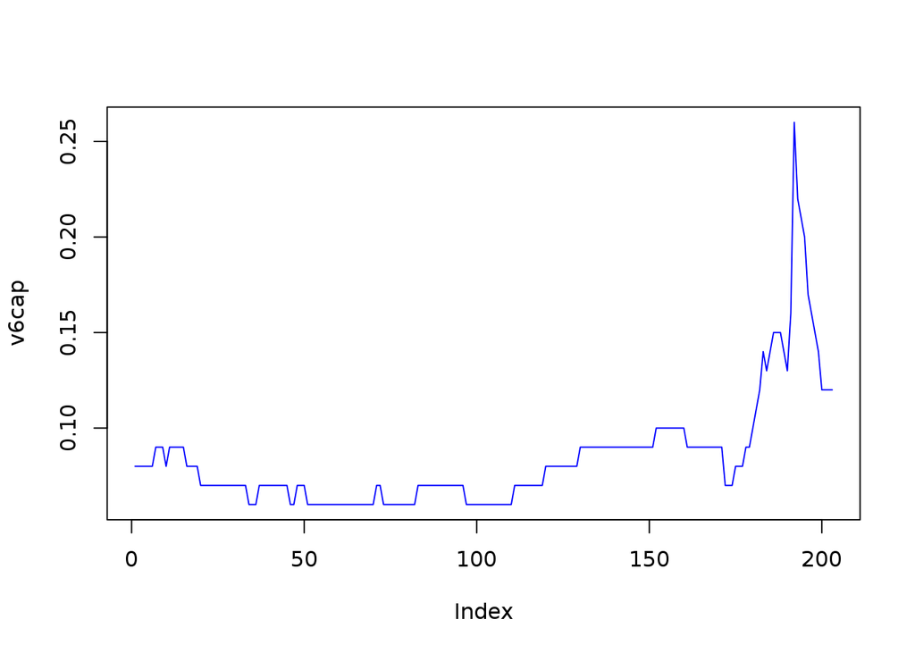

## Actividad para el ASN 28126

- Nombre organización: **BRISANET SERVICOS DE TELECOMUNICACO**
- Promedio de actividad IPv6 ultimos 30 dias: 0.01 %
- Máximo de actividad IPv6 ultimos 30 dias: 0.01 %
- Promedio de actividad IPv6 ultimos 360 dias: 0.0558937198067632 %
- Máximo de actividad IPv6 ultimos 360 dias: 0.26 %

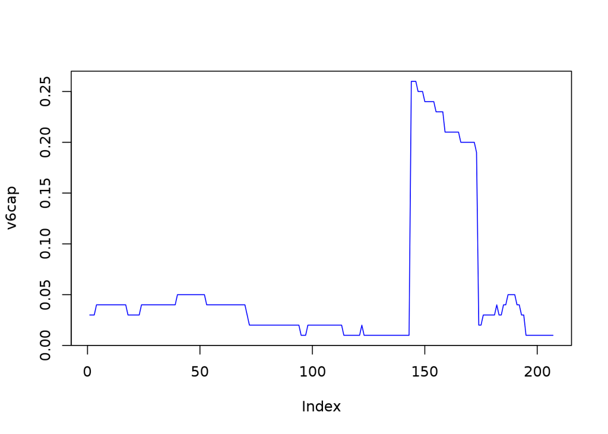